# Seattle Public Library Trends of My Favorite Childhood Authors

Mark Manlimos

2/24/2023

### Introduction

Once an integral part of my youth education, going to the library has become more optional and therefore inconvenient for my education. With the accelerated rise of technology as a medium for knowledge, libraries have become underutilized by myself an much of the youth. As a kid I loved to read the Rick Riordan’s “Percy Jackson” and “The Kane Chronicles” series and J.K. Rowling’s “Harry Potter” series. As I aged into late middle school, I really got into J.R.R Tolkien’s “Lord of the Rings” series.

This report looks to explore the trends of book Mediums and compare how people take in books nowadays. I also am interested in seeing how my favorite books as a kid compare to each other today and to see what medium people are choosing to absorb these books through.

I will focus on:

- Authors:
  - Specifically the three mentioned above
- Book Medium:
  - This will look different in different sections. Sometimes I will focus on specific mediums such as EBOOKS and audio books, and sometimes I will focus on just digital vs. physical
- Time:
  - The element of time will only pertain to the year 2022 as that is the limitation of my data set.

My report will connect the three of these focuses and analyze information taken from combinations of the three.

### Summary Information

Based on this data, I was able to conclude that in 2022, **January** was the month that had the highest increase in checkouts from the month before. Also, **December** was the month where the least amount of physical books was checked out in.

I was also able to find out that throughout the entire year it is still the medium of **BOOK** . And out of these books, **The House of Broken Angels** was the most checked out book.

I also chose to take a look at one of my favorite authors as a child. Of Rick Riordan’s books, **The Lightning Thief: Percy Jackson and the Olympians Series, Book 1 (unabridged)** was the most checked out book in 2022.

### The Dataset

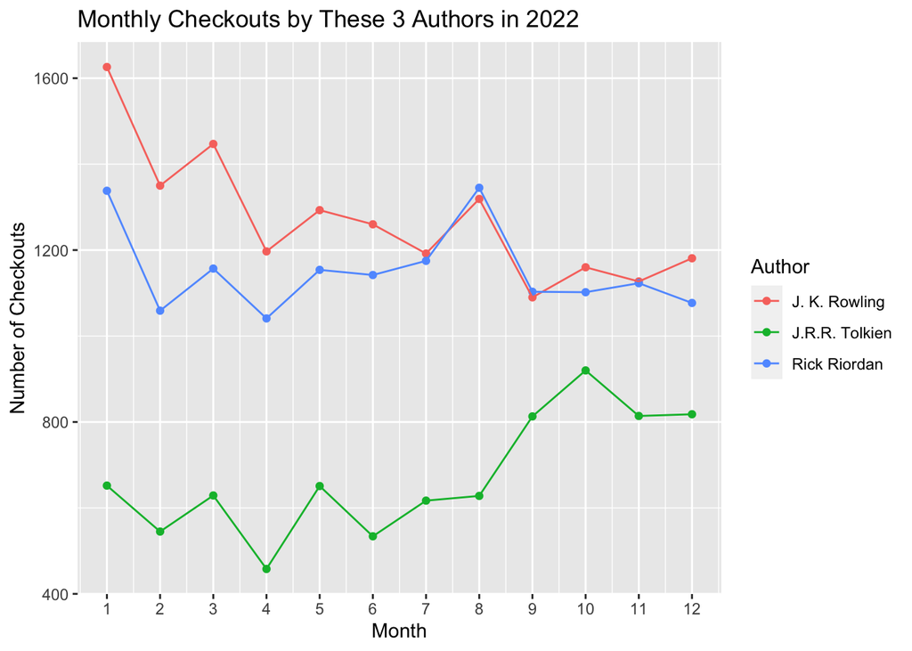

#### Purpose

The purpose of this chart was the compare my 3 most read authors as a kid and see how their works compared to one another over the course of 2022

#### Insights

According to this chart J.K. Rowling was on average the most checked out author in 2022 (between these three). You can also see that besides J.R.R Tolkien, the checkouts of the books decreases throughout the year.

### Second Trends Over Time Chart

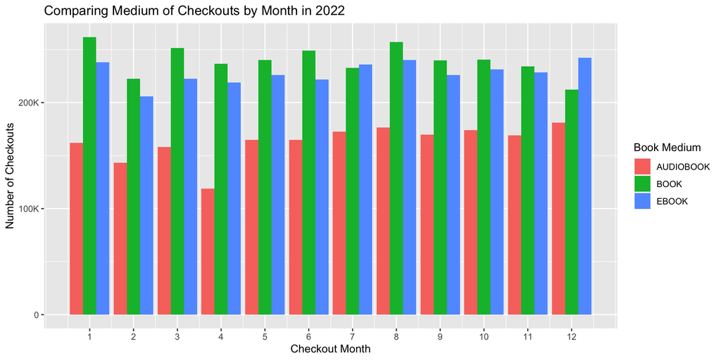

#### Purpose

The purpose of this chart was to compare how the number of checkouts of the 3 biggest book mediums compared throughout each month of 2022

### Your Choice

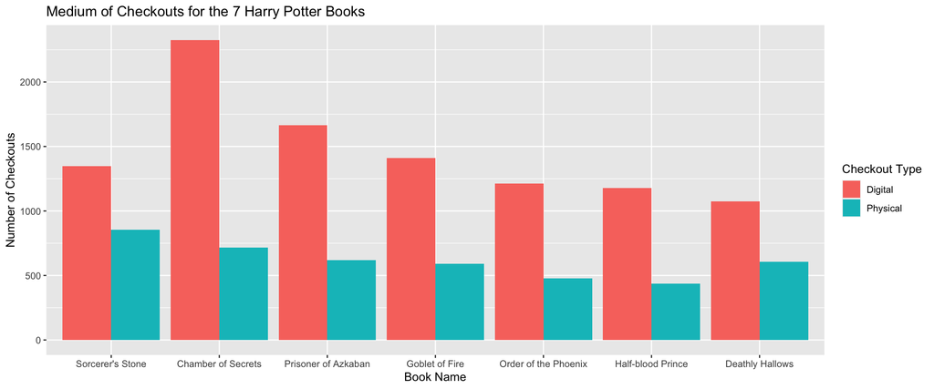

#### Purpose

The purpose of this chart was to see how much (if at all) the way of consuming one of my favorite series has changed since I was a kid. When I was a kid, reading the hardcovers of Harry Potter books gave you more status than reading the paper backs. However, now I look to compare if people even read physical books anymore. This chart was made to compare physical vs digital consumption of each Harry Potter book in the original series.

#### Insights

Based on the chart, across the board, in 2022, more people checked out the Harry Potter books in a digital form. This statistic was the most surprising to me, but also the most representative of where we are headed in the future.